Panelwright · introduction

# Panelwright — an introduction

# Panelwright — an introduction

**Playwright for the mainframe terminal.** Panelwright drives IBM 3270 applications — TSO, ISPF, CICS, IMS, anything behind a "green screen" — from the command line, from a real terminal UI, and from AI agents. It is pure TypeScript with zero runtime dependencies, talks TN3270/TN3270E directly, and has been validated live against z/OS, MVS 3.8j (TK5) and Galasa SimBank.

The CLI and TUI screenshots below were captured live on 2026-08-27 against TK5 (MVS 3.8j under Hercules) with Panelwright's own tooling. The VS Code screenshots (2026-09-04) run the extension's real production code inside a real VS Code window, attached to a real captured TK5 screen played back through a scriptable test host — nothing here is mocked or hand-drawn.

## Why Panelwright

| **No API? No problem.** | Decades of mainframe applications only exist as screens. Panelwright automates them exactly as an operator would — type into fields, press ENTER/PF keys, read what came back. |
| --- | --- |
| **Built for agents, not just scripts.** | One CLI command per action, and after each one the CLI prints a *compact, deterministic view of what changed*. An AI agent can see the terminal it is driving without screen-scraping ANSI. |
| **Humans stay in the loop.** | A person can watch an agent's session live, take over when a screen needs judgment, and hand control back — all through one shared session. |
| **Safe by default.** | Passwords never touch the command line, the action journal, or a wire trace: `--secret-env`, credential-aware redaction, and secret references in place of values. |
| **Evidence, not guesswork.** | Wire traces decoded in readable form, annotations, screen exports as SVG/ANSI, and a replayable fake host for hermetic tests. |
| **Real terminal work, done well.** | A modern TUI and a native VS Code panel, both with a command palette, autocomplete, find-on-screen, file transfer, 124 host code pages and coaching hints. |

## The CLI in 60 seconds

Log on to TSO on a real MVS system: connect, type into a field found by its label, submit the password from an environment variable, and page through the line-mode `***` prompts in one call.

[figure not shown]

Three things to notice:

- **You address fields by what's next to them** — `after:"Logon ===>"`, `below:"PASSWORD FOR HERC01"` — not by row/column coordinates. Also available: `rightOf:`, `above:`, composition (`after:Name,below:"Section"`), the field index from `fields`, `last` for the active line on scrolling line-mode screens, and `at:row,col` as an escape hatch.
- **Output is the diff.** The header line names the screen, cursor, field count and keyboard state; below it only the rows that changed are printed, with writable fields marked `[n:____]`. A whole ISPF panel repaint prints the whole panel; a two-line status update prints two lines.
- **Line-mode TSO is handled**, not fought: `press ENTER --until-gone "***"` drains a paged display, `wait --text READY --last-line` matches only the live prompt, and `type` warns if it is about to write into a pager prompt.

Then drive ISPF and log off cleanly:

[figure not shown]

A background daemon holds the connection, screen buffer and cursor between CLI invocations, so each command is a short-lived process and sessions survive across shells. Distinct `--session` names run several hosts at once.

### Commands at a glance

| Command | What it does |
| --- | --- |
| `connect` / `disconnect` / `sessions` | Open, close and list sessions (`--model 2..5`, `--oversize`, `--tls`, `--codepage`, profiles from config) |
| `screen` / `fields` | Compact or full screen view, field listing; `--json` for programs, `--format svg/ansi` for color exports |
| `type` / `press` / `cursor` / `wait` | The four verbs of terminal work — with locators, AID keys, point-and-shoot cursor targets and screen conditions |
| `transfer` | IND$FILE upload/download, text or binary, with host code-page conversion |
| `journal` | Every action the session took, replayable — or exported as a runnable script |
| `trace` / `annotate` | Wire capture for bug reports, decoded into c3270's own vocabulary, credentials scrubbed; free-text notes stamped with screen identity |
| `control` | The agent ↔︎ human handoff: request, take, grant, lock, listen |
| `complete` / `secret` / `config` / `scripts` / `trust` | Autocomplete corpus, password autofill setup, layered JSON config with profiles, user scripts and their trust review |
| `doctor` | A privacy-safe connection diagnostic bundle for a bug report — never captures screen content, only negotiation/timing/environment |
| `keytest` | A guided walk that finds out what each PF key actually does in an application you don't know yet |
| `ui` | The interactive TUI (below) |
| `install --skills` | Installs the Claude Code skill that teaches an agent all of the above |

Every command has `--help`; exit codes are stable and documented so a script or an agent can branch on `locator not found` vs `timeout` vs `lease held`.

## How it fits together

One background daemon per user owns the live TN3270 connections; every client — the CLI, the TUI, an agent, a user script — talks to it over a local socket. Two dependency-free libraries do the real work underneath, and a fake host lets all of it be tested without a mainframe.

```
flowchart TB
  subgraph clients["Clients"]
    direction LR
    AG["AI agent
(Claude Code skill)"] --> CLI["panelwright CLI
one command per action"]
    TUI["panelwright ui
manual / watch mode"]
    VSC["VS Code extension
screen panel · Sessions/Profiles trees"]
    CFG[/"Config layers
user · project · local
profiles — no secret values"/]
  end

  subgraph daemon["Per-user daemon"]
    direction LR
    REC["Journal · wire trace
annotations
(credentials redacted)"]
    SM["Session manager
sessions · writer lease
human ↔ agent handoff"]
    SH["Script hosts
recognizers · commands
event handlers"]
  end

  subgraph libs["Libraries — pure TypeScript, zero dependencies"]
    direction LR
    CORE["@panelwright/core
locators · compact/diff rendering
auto-waiting · IND$FILE"] --> PROTO["@panelwright/protocol
TN3270E · 3270 data stream
EBCDIC code pages · screen buffer"]
  end

  HOST[("Mainframe host
TSO · ISPF · CICS · IMS")]
  TS["@panelwright/test-server
fake host for hermetic tests"]

  CFG -.-> CLI
  CFG -.-> TUI
  CFG -.-> VSC
  CLI -- "RPC over unix socket" --> SM
  TUI -- "subscribe: live screen
+ activity feed" --> SM
  VSC -- "subscribe: live screen
+ activity feed" --> SM
  SM --> REC
  SM --> SH
  SM --> CORE
  PROTO -- "TN3270 / TLS" --> HOST
  PROTO -. "same wire protocol" .-> TS
```

- **Sessions outlive processes.** The daemon keeps the connection, screen buffer, cursor and journal; CLI invocations are short-lived, and a TUI or a second agent can attach to the same session at any time.
- **One writer at a time.** A writer lease and the `control` protocol decide who is driving — an agent or a person — while any number of watchers subscribe read-only.
- **Config is resolved client-side**, so one daemon serves many projects with different profiles; secrets are referenced by name, never stored.

## For AI agents

Panelwright's primary design goal is that an LLM-based agent can operate a mainframe application competently and safely, step by step, with a human able to supervise.

**The output contract is the agent's eyes.** After each action the agent gets a one-line summary plus only the rows that changed — small enough to fit in context on every turn, deterministic enough to reason about, and including the `[n:____]` field markers it needs to pick the next target.

**A Claude Code skill ships in the box.** `panelwright install --skills` installs a skill that covers the session model, locator grammar, waiting, line-mode TSO hazards, the password rules and the handoff protocol. From then on, "log on to the mainframe and list my data sets" is a prompt. The VS Code extension notices when Claude Code is installed and the skill is not, and offers to install it — globally or into the open project — with one click.

**Everything the agent does is on record.** The journal captures each action with the screen fingerprint it saw, with secrets redacted — useful for review, for debugging, and for turning a successful run into a script (`journal export --script`).

[figure not shown]

**A human can watch live, and take over.** `panelwright ui --watch` attaches a read-only view of the same session with an activity feed of the agent's actions as they happen. Press `t` to take control when a screen needs a person; the agent, meanwhile, can ask for exactly that with `panelwright control request --reason "…"` and block until control is handed back — or stand by with `control listen` while a human drives their own emulator ("tell me when READY comes up").

[figure not shown]

**Secrets are handled structurally, not by convention.** `type --secret-env VAR` or `--secret-profile <name>` keeps a password out of shell history, the journal, the TUI feed and the wire trace; the daemon also recognizes password-shaped writes on its own (hidden fields, `PASSWORD` prompts) and redacts them regardless of how they were typed. Config files carry only *references* to secrets, never values, and `config validate` refuses secret-shaped keys.

**Scripts extend what the agent (and you) can do.** A project can ship `defineSpec({…})` modules that recognize application panels (so the TUI and the journal name them — `[panel: ISP@PRIM]` in the frame above), expose commands callable from the palette or `scripts run`, and react to events such as `connect` or `panel:<glob>`. Scripts from committed layers are hash-trusted and reviewed before they run.

## The interactive terminal UI

`panelwright ui` is a full 3270 terminal in your own terminal — the same daemon session the CLI and agents use, so you can step in at any point.

[figure not shown]

Manual mode is a faithful 3270: field-aware editing, insert/overtype, Tab/Home/End between fields, PF1–PF24/PA/CLEAR/RESET, an OIA row with the keyboard state, and colors driven by the host's own attributes. On top of that:

- **Command palette (`Ctrl+P`)** — every action and setting, searchable.
- **Locator picker (`Ctrl+L`)** — click or arrow to a field and copy the locator an agent would use (`after:"Option"`), bridging the human and the CLI vocabulary.
- **Autocomplete (`Ctrl+O`)** — remembered values per panel and field, TSO command history, and one-keystroke password autofill from a connection profile's secret source — the password itself never appears.
- **Find on screen (`Ctrl+F`)** and **search docs (`Ctrl+S`)** for whatever is under the cursor.
- **Mouse hotspots** — click an ISPF menu option, a PF-key legend entry, an action-bar item or a pull-down entry and the right thing is typed/pressed; a palette toggle highlights every clickable span before you hover.
- **Session tabs** — `Ctrl+T` opens a new connection, `Ctrl+W` detaches the focused tab (the session keeps running), `Ctrl+B` cycles — one process, several hosts, each tab with its own live subscription.
- **File transfer dialog** (IND$FILE), **screen code-page switching** mid-session, terminal models 2–5 / oversize / auto-fit, themes, custom key bindings, and **Save UI Settings** to persist your choices.
- **A coach** — an opt-out, non-nagging hint when you do something the long way ("5 Tabs to the last field → `End`").
- **Notes (`Esc n`)** — record what you saw; the note is stamped with the panel identity and exported with the session's wire trace on exit.

[figure not shown]

## The VS Code extension

`@panelwright/vscode` puts a 3270 screen in an ordinary editor tab — the same daemon session the CLI, the TUI and any agent are already using, so you can open it, close it, and come back without ever ending the connection.

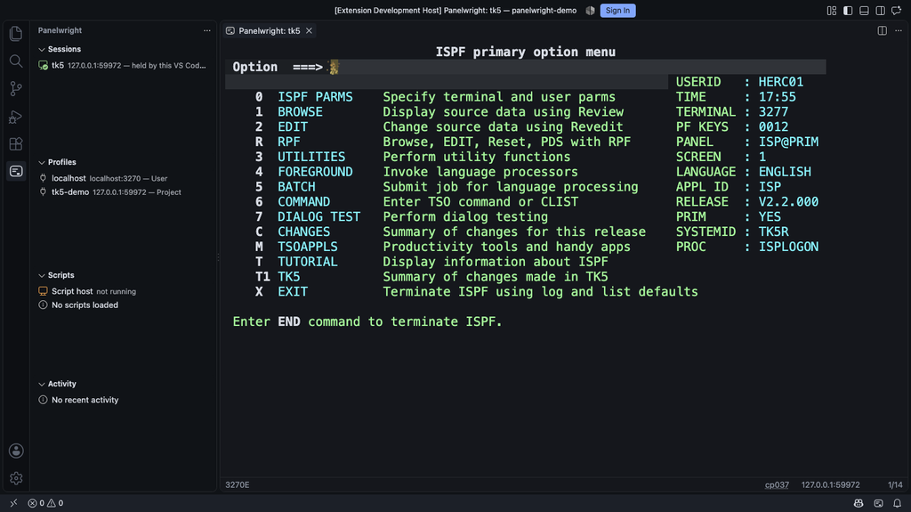

- **A real, colored, typeable panel.** PF1–PF12/PF13–PF24, the same field editor as the TUI (Tab/Backtab, insert mode, DUP/FIELD MARK, Erase EOF/Input), local echo so typing never waits on a round trip, an OIA strip that shows keyboard lock and wait state, and native selection/copy/paste/find. A screen with no fields at all — KICKS' transaction-entry screen, say — takes what you type straight at the cursor, like a real terminal.
- **Click what's clickable.** PF-key legends, ISPF menu options, action-bar entries and pull-down items light up and act on hover; a Ctrl/Cmd-click on a dataset name opens it straight in **Zowe Explorer**, and one on a job id opens that job's spool output there, if it's installed.
- **The same coach as the TUI, as toasts.** Reach the last field with five Tabs, run PF3 from the command palette three times, click into the next field four times in a row — and a small info toast names the key that would have done it. Three per session at most, never the same hint twice, retired the moment you use the shortcut yourself, and one button turns it off.
- **Sessions and Profiles trees**, including Zowe team configuration read in read-only — an existing `zowe.config.json` becomes connection profiles with no extra setup, and the extension never invokes the `zowe` CLI itself.
- **Autocomplete, transfer, export and the trace viewer** all carry over from the daemon — `Ctrl+O` for remembered values and secret-safe password fill, the same IND$FILE dialog as the TUI, screen exports to SVG/ANSI/text, and a saved wire trace opens as a structured, filterable editor instead of a wall of JSON.
- **One writer at a time, same as everywhere else.** Attaching takes the session's writer lease if it's free; otherwise the panel opens read-only and says who has it — exactly like the TUI and the CLI's own handoff protocol.
- **A few purely cosmetic flourishes** — a faint background image behind the screen, and a cursor effect (`pulse`, `raster`, `crosshair`, `sparkle`, `trail`, `chad`, `phosphor`, `beam`, or the `fire` cursor above), off by default and respecting your OS's reduced-motion setting.

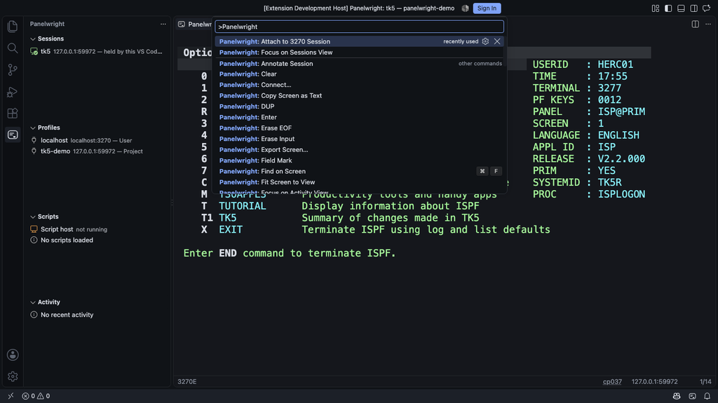

`@panelwright/vscode` is an early preview: sideloaded from a `.vsix` (with the CLI bundled inside it) rather than published to the Marketplace yet, but it's used daily against real hosts. `packages/vscode/README.md` has the full feature list and settings reference.

## Color-faithful screen exports

`panelwright screen --format svg` (or the palette's *Save Screen as SVG*) writes the current screen with the host's real field and extended-color attributes — the format GitHub renders inline, ideal for issues, wikis and runbooks. `--format ansi` does the same for a real terminal.

[figure not shown]

## Configuration and profiles

Four strict-JSON layers, most specific wins: built-in defaults → `~/.config/panelwright/config.json` → `.panelwright/config.json` (committed) → `.panelwright/config.local.json` (gitignored). Named connection profiles (`panelwright connect prod`) carry host, port, TLS, terminal model, code page and the *name* of the secret source — an environment variable or a credential command (1Password, Touch ID…). `panelwright secret init <profile>` sets that up in one guided step. `config list` shows where every value came from.

## Roadmap

Panelwright is feature-complete for its core and used daily against real hosts; it is not yet on npm. What's next, in rough order of user impact:

**Next up**

- **npm release** of `@panelwright/cli` — one `npm install -g` instead of a checkout (a rolling `edge` tarball already ships from CI); the same tarball is bundled inside the VS Code `.vsix` and offers to install itself.
- **VS Code Marketplace release** — the extension is sideloaded from a `.vsix` today; publishing is the remaining step.
- **Smarter errors** — a locator that matches nothing suggests the nearest field; `cursor` errors list nearby targets.
- **`panelwright explain`** — one call that orients an agent (or a newcomer) on the current screen: what it is, what's writable, what the likely next actions are.
- **Host message-ID explainer** — hover or ask about `IKJ56425I`, `ISPI001` and friends, in the TUI and the CLI.

**Planned**

- **MCP server** (`@panelwright/mcp`) — the same daemon, exposed as MCP tools and push-fed screen resources, for agents that aren't Claude Code.
- **`panelwright doctor`, deeper** — per-screen structural capture, `--interactive`, `--replay` and `--submit` on top of the connection/ negotiation diagnostics it already writes today.

**Ideas being explored**

- Screen translation (render-side only — the host sees the original bytes).
- End-of-session coaching summary and "you've done this three times — save it as a profile/script?" nudges.
- Reconnect/keepalive for long-idle sessions; DBCS host code pages; TLS validation against a real TLS 3270 host.

The full, prioritized list with design pointers is [`BACKLOG.md`](https://github.com/plavjanik/panelwright/blob/main/BACKLOG.md); what has shipped, with dates, is [`CHANGELOG.md`](https://github.com/plavjanik/panelwright/blob/main/CHANGELOG.md).

## Try it

```bash
git clone <this repo> && cd panelwright
npm install && npm run build
npm run cli:link              # puts `panelwright` on your PATH

panelwright connect mainframe.example.com:23
panelwright screen
panelwright ui --watch        # in a second terminal
```

No mainframe at hand? `docker/tk5/` builds a self-contained MVS 3.8j image (the one in these screenshots) — `docker run -d --name tk5 --privileged -p 3270:3270 panelwright/tk5`, wait for it to report healthy, and log on as `HERC01`/`CUL8TR`.

For the VS Code extension: `npm run vsix` builds `dist-pack/ panelwright-<version>.vsix`, then `code --install-extension dist-pack/panelwright-<version>.vsix` sideloads it (it bundles the CLI, so nothing else to install).

Further reading: the top-level [README](https://github.com/plavjanik/panelwright/blob/main/README.md), the CLI reference in [`packages/cli/README.md`](https://github.com/plavjanik/panelwright/blob/main/packages/cli/README.md), the TUI reference in [`packages/tui/README.md`](https://github.com/plavjanik/panelwright/blob/main/packages/tui/README.md), and the host matrix in [`COMPATIBILITY.md`](https://github.com/plavjanik/panelwright/blob/main/docs/COMPATIBILITY.md).

Source: docs/INTRO.md. Other pages: The Making of Panelwright.